# lab1

Tatiana Kichigina

8.10.17

## Лабораторная работа 1

Проверка следующих навыков: Манипулирование объектами данных; использование встроенных функций; построение простейших графиков; простейшие статистические концепции.

# Исходные данные

Экспоненциальное распределение определяется следующей функцией распределения:

`F(x) = 1 - e^(-λ⋅x)`

Функция `rexp` генерирует случайные переменные при помощи экспоненциального распределения `rexp(n=42, rate=5)` вернёт 42 экспоненциально-распределённых числа с параметром (λ) равным 5. Ели второй аргумент не указан, будет использовано значение 1 т.е. получим “стандартное экспоненциальное распределение”.

# Задание 1

1.Сгенерируйте 200 случайных значений из стандартного экспоненциального распределения и сохраните в вектор exp.1. Найдите среднее и стандартное отклонение из данных этого вектора.

```r
exp.1<-rexp(200)
mean.exp.1<-mean(exp.1)
sd.exp.1<-sd(exp.1)
mean.exp.1
```

```
## [1] 0.910621
```

```r
sd.exp.1
```

```
## [1] 0.9518079
```

2.Повторите, использовав следующие значения параметра λ: 0.1, 0.5, 5, 10, и сохраните результаты в векторы: exp.0.1, exp.0.5, exp.5, exp.10.

```r
exp.0.1<-rexp(200, 0.1)
mean.exp.0.1<-mean(exp.0.1)
sd.exp.0.1<-sd(exp.0.1)
mean.exp.0.1
```

```
## [1] 10.071
```

```r
sd.exp.0.1
```

```
## [1] 9.419985
```

```r
exp.0.5<-rexp(200, 0.5)
mean.exp.0.5<-mean(exp.0.5)
sd.exp.0.5<-sd(exp.0.5)
mean.exp.0.5
```

```
## [1] 2.053284
```

```r
sd.exp.0.5
```

```
## [1] 1.856687
```

```r
exp.5<-rexp(200, 5)
mean.exp.5<-mean(exp.5)
sd.exp.5<-sd(exp.5)
mean.exp.5
```

```
## [1] 0.1963949
```

```r
sd.exp.5
```

```
## [1] 0.1770451
```

```r
exp.10<-rexp(200, 10)
mean.exp.10<-mean(exp.10)
sd.exp.10<-sd(exp.10)
mean.exp.10
```

```
## [1] 0.09983509
```

```r
sd.exp.10
```

```
## [1] 0.09769017
```

3.Функция `plot()` общая функция для визуализации данных. Функция `hist()` принимает данные и раскладывает их по корзинам. Чтобы использовать эти функции нужно для начала передать им данные, которые хотим визуализировать.

4.Используйте функцию `hist()` для построения гистограммы полученного ранее стандартного распределения.

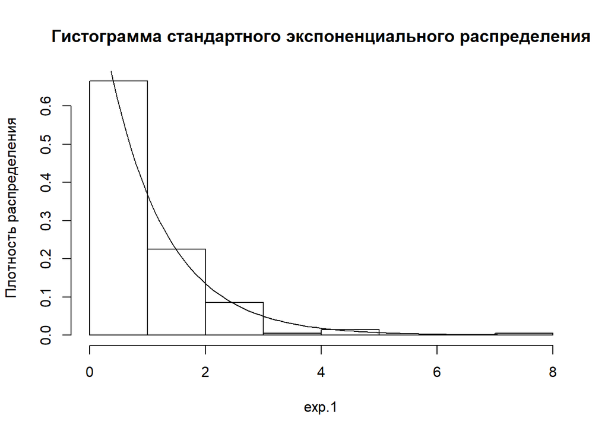

```r
hist(exp.1, prob = TRUE, main = "Гистограмма стандартного экспоненциального распределения", ylab="Плотность распределения")
curve(dexp(x), from = 0, to = 8, add = TRUE)
```

Вид полученной гистограммы соответствует виду стандартного экспоненциального распределения.

5.Используйте функцию `plot()` с тем же самым вектором для построения графика значений в порядке следования.

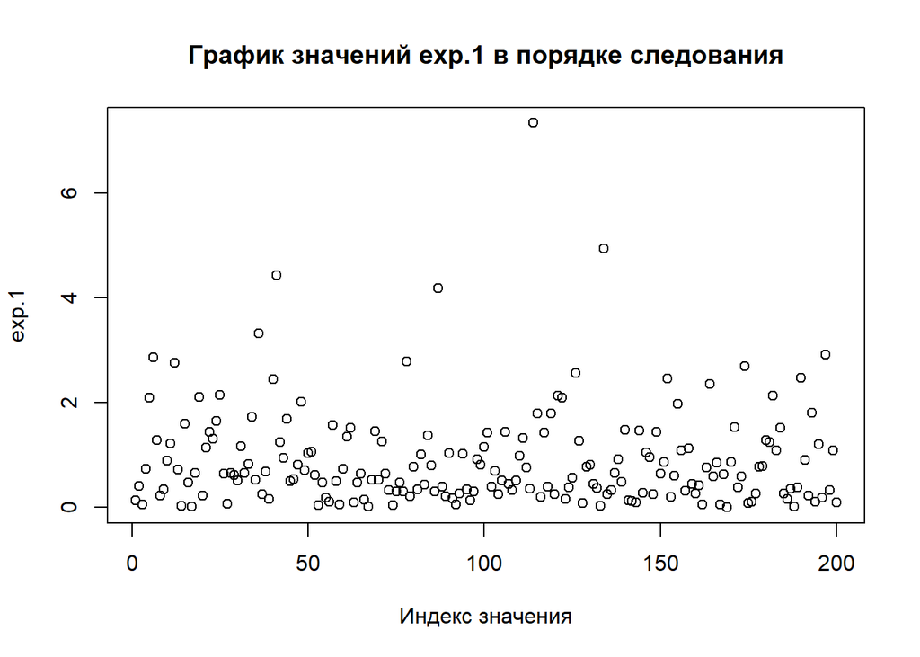

```r
plot(exp.1, xlab="Индекс значения", main="График значений exp.1 в порядке следования")
```

По полученному графику значений `exp.1` видно, что у стандартного экспоненциального распределения, как и у любого друго неравномерного распределения, присутствует разброс знаяений, а относительно малые и большшие значения генерируются в случайном порядке.

6.Используйте функцию `plot()` с любыми двумя полученными ранее векторами, чтобы получить диаграмму рассеяния (scatterplot) этих векторов относительно друг друга.

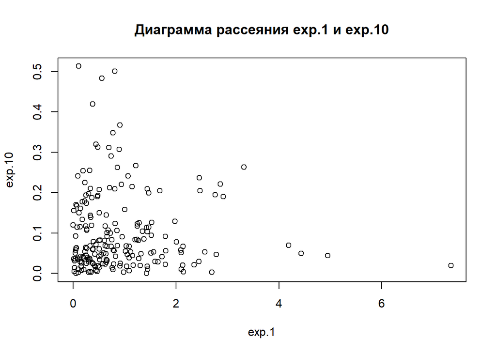

```r
plot(exp.1, exp.10, main="Диаграмма рассеяния exp.1 и exp.10")
```

Полученная диаграмма рассеяния `exp.1` и `exp.10` показывает, что между рассматриваемыми векторами нет выраженной связи.

7.Теперь сравним свойства всех наших векторов. Для начала создадим вектор, содержащий средние значения каждого из 5 полученных ранее распределений в порядке их создания. Полученный вектор сохраним в переменную `exp.means`.

```r
exp.means<-c(mean.exp.1, mean.exp.0.1, mean.exp.0.5, mean.exp.5, mean.exp.10)
exp.means
```

```
## [1]  0.91062099 10.07100136  2.05328393  0.19639491  0.09983509
```

Далее необходимо создать следующие диаграммы рассеяния: 8.Вектор с пятью средними относительно каждого из пяти векторов с различными значениями λ.

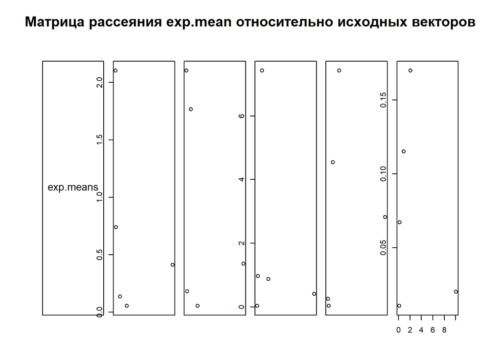

```r
pairs(~exp.means+exp.1[1:5]+exp.0.1[1:5]+exp.0.5[1:5]+exp.5[1:5]+exp.10[1:5], main="Матрица рассеяния exp.mean относительно исходных векторов", horInd=1)
```

Полученные диаграммы рассеяния говорят о том, что между вектором средних и векторами распределений с различными значениями λ нет однозначной связи.

9.Вектор с пятью стандартными отклонениями относительно каждого из пяти векторов с различными значениями λ.

```r
exp.sd <- c(sd.exp.1, sd.exp.0.1, sd.exp.0.5, sd.exp.5, sd.exp.10)
exp.sd
```

```
## [1] 0.95180789 9.41998521 1.85668715 0.17704510 0.09769017
```

[figure not shown]

```r
pairs(~exp.sd+exp.1[1:5]+exp.0.1[1:5]+exp.0.5[1:5]+exp.5[1:5]+exp.10[1:5], main="Матрица рассеяния exp.mean относительно исходных векторов", horInd=1)
```

10.Вектор с пятью средними относительно вектора с пятью стандартными отклонениями. Для каждого графика, поясните увиденное.

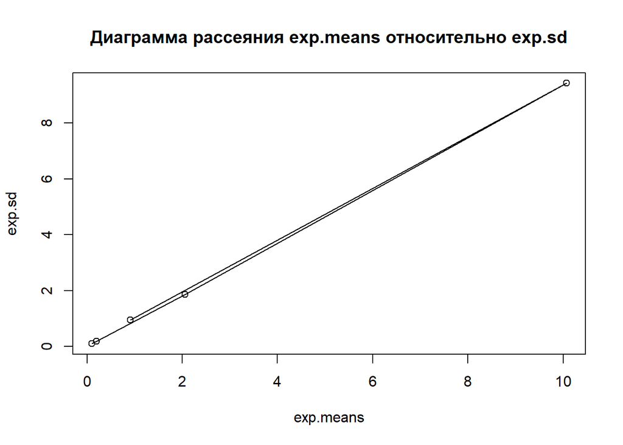

```r
plot(exp.means, exp.sd, main="Диаграмма рассеяния exp.means относительно exp.sd")
lines(exp.means, exp.sd)
```

Полученная диаграмма рассеяния `exp.means` и `exp.sd` говорит о однозначной линейной зависимости между векторами со средними и со стандартными отклонениями.

# Задание 2

R достаточно производителен, чтобы вычислять относительно большие объёмы данных.

1.Для демонстрации сгенерируйте 1100000 (1 млн. 100 тысяч) чисел из стандартного экспоненциального распределения и сохраните их в вектор `huge.exp.1`. Получите среднее и стандартное отклонение.

```r
huge.exp.1<-rexp(1100000)
mean.huge.exp.1 <- mean(huge.exp.1)
sd.huge.exp.1<-sd(huge.exp.1)
mean.huge.exp.1
```

```
## [1] 0.998135
```

```r
sd.huge.exp.1
```

```
## [1] 0.9983787
```

2.Получите гистограмму `huge.exp.1`. Она соответствует функции `1 - e:^(-x)`? Должна ли?

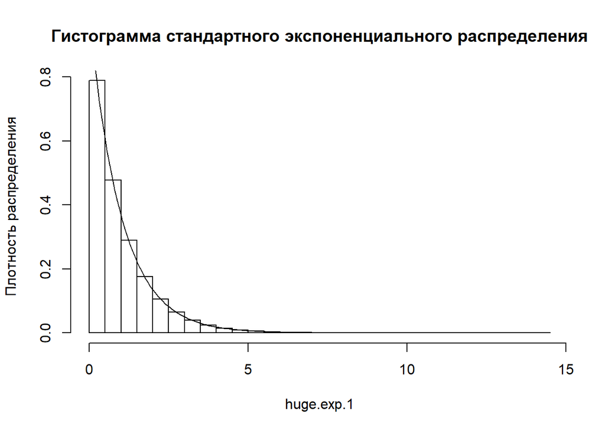

```r
hist(huge.exp.1, prob = TRUE, main = "Гистограмма стандартного экспоненциального распределения", ylab="Плотность распределения")
curve(dexp(x), from = 0, to = 8, add = TRUE)
```

3.Получите среднее всех чисел из `huge.exp.1` строго больших 1. Для проверки выборки может потребоваться новый вектор.

```r
huge.exp.1.greater.1<-huge.exp.1>1
mean.exp.1.greater.1<-mean(huge.exp.1.greater.1)
mean.exp.1.greater.1
```

```
## [1] 0.3673318
```

4.Получите матрицу `huge.exp.1.mat`, содержащую 1100 строк и 1000 колонок. Постройте гистограмму, использовав полученную матрицу. Что можно сказать о полученных данных?

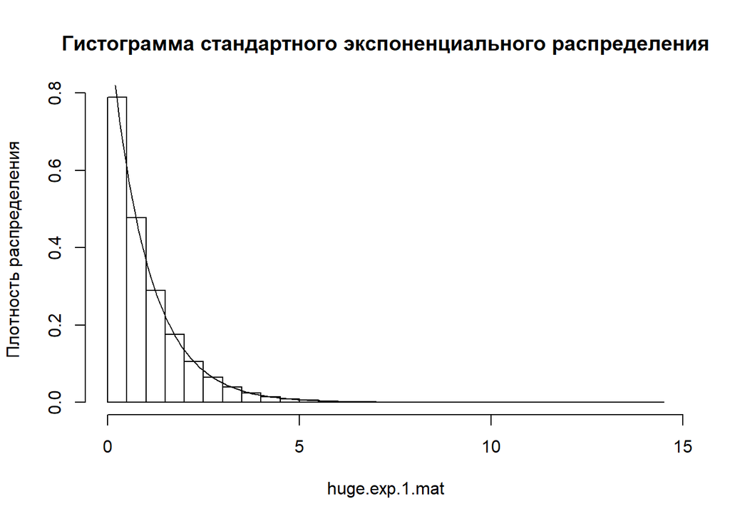

```r
huge.exp.1.mat<-matrix(huge.exp.1, nrow=1100, ncol=1000)
hist(huge.exp.1.mat, prob = TRUE, main = "Гистограмма стандартного экспоненциального распределения", ylab="Плотность распределения")
curve(dexp(x), from = 0, to = 8, add = TRUE)
```

Полученная гистограмма аналогична диаграмме, полученной в пункте 2, т.о. можно сделать вывод о том, что вид диаграммы не зависит от способа представления входных данных.

5.Рассчитайте среднее 137-й колонки из `huge.exp.1.mat`.

```r
colMeans(huge.exp.1.mat)[137]
```

```
## [1] 0.9683204
```

6.Найдите среднее всей 1000 колонок и сохраните их в вектор. Отобразите диаграмму средних зннчений колонок. Объясните почему форма диаграммы отличается от виденных ранее.

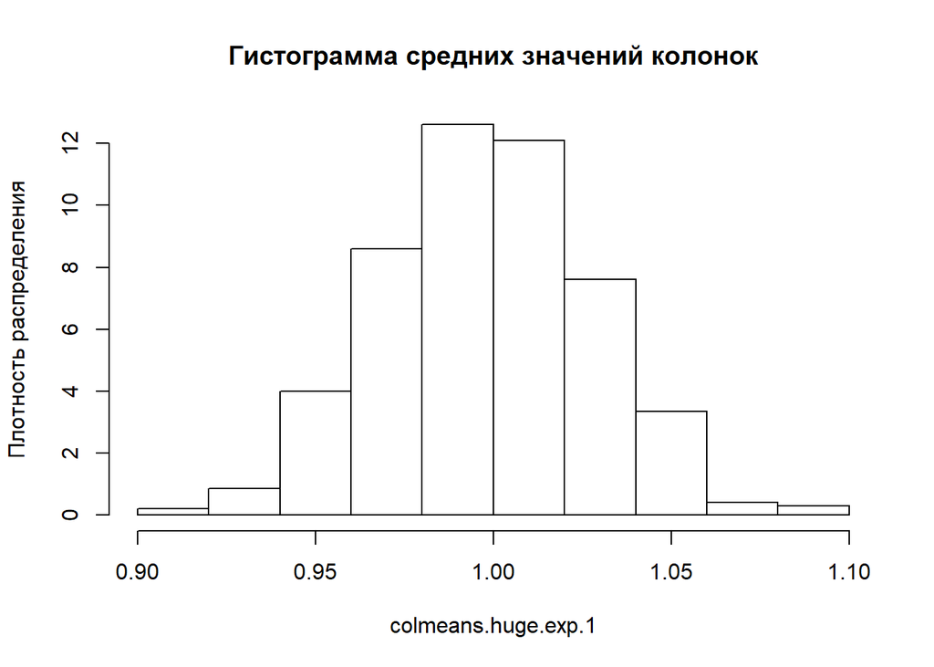

```r
colmeans.huge.exp.1<-colMeans(huge.exp.1.mat)
hist(colmeans.huge.exp.1, prob = TRUE, main = "Гистограмма средних значений колонок", ylab="Плотность распределения")
```

Полученная диаграмма имеет такой вид, т.к. среднее значение экспоненциального распределения равно 1/λ. В данном случае λ равно 1, поэтому среднее значение каждой колонки стремится к 1.

7.Рассчитайте квадрат каждого значения из `huge.exp.1` и найдите среднее и стандартное отклонение полученного вектора квадратов. Объясните отличие от соответствующих показателей вектора `huge.exp.1`. Вам может помочь формула, по которой R рассчитывает стандартное отклонение: `sqrt(sum((x - mean(x))^2) / (n - 1))`.

```r
huge.exp.square.1<-huge.exp.1^2
mean.huge.exp.square.1<-mean(huge.exp.square.1)
sd.huge.exp.square.1<-sd(huge.exp.square.1)
mean.huge.exp.1
```

```
## [1] 0.998135
```

```r
mean.huge.exp.square.1
```

```
## [1] 1.993033
```

```r
sd.huge.exp.1
```

```
## [1] 0.9983787
```

```r
sd.huge.exp.square.1
```

```
## [1] 4.457427
```

Среднее значение увеличивается при увеличении суммы всех элементов, что подтверждают полученные знаения `mean.huge.exp.1` и `mean.huge.exp.square.1`. Стандартное отклонение увеличивается при увеличении значения каждого из элементов, что подтверждают полученные знаения `sd.huge.exp.1` и `sd.huge.exp.square.1`.